# Opponent tendency report

Indianapolis Colts offense Scouting report for the Dolphins · 2026 Week 10 · Dolphins at Colts, Sun Nov 15, 2026 Line: MIA +4.5 · O/U 37.5 · Model estimate (Elo v1 (cloud)): MIA 45% to win (market 34%). Not betting advice. Data through Week 9 (9 games). Only games before this week are used. Ranks are among all 32 teams.

### Roster changes: IND lost WR Josh Downs, lost WR Keenan Allen, lost DT DeForest Buckner, lost G Quenton Nelson; MIA added G Christian Haynes

| Date | Team | Player | Move | Before the move | Games since |
| --- | --- | --- | --- | --- | --- |
| Nov 9 | IND out | ⚠ WR Josh Downs | to KC (roster) | 81% of IND off. snaps, 9 games, 20% of targets | 0 of 9 |
| Nov 9 | IND out | ⚠ WR Keenan Allen | to SF (roster) | 58% of IND off. snaps, 8 games, 20% of targets | 0 of 9 |
| Oct 27 | IND out | ⚠ DT DeForest Buckner | to SF | 83% of IND def. snaps, 7 games | 2 of 9 |
| Oct 27 | IND out | ⚠ G Quenton Nelson | to SEA | 99% of IND off. snaps, 7 games | 2 of 9 |
| Oct 26 | MIA in | ⚠ G Christian Haynes | from SEA (roster) | 60% of SEA off. snaps, 5 games | 2 of 8 |

⚠ IND’s numbers below cover 9 games: 9 before Josh Downs left; 9 before Keenan Allen left; 7 before DeForest Buckner left; 7 before Quenton Nelson left.

nflverse’s trade feed has nothing after Aug 28, 2025; newer trades come from the hand-kept list and weekly rosters.

### 3 things to know

1. **Early downs:** 2nd-least efficient offense, -0.16 EPA per play (league avg +0.00). 391 plays
2. **Trailing by 8+:** 2nd-least efficient offense, -0.21 EPA per play (league avg +0.02). 133 plays
3. **2-minute:** 2nd-least efficient offense, -0.33 EPA per play (league avg +0.00). 78 plays

### Early downs: close to the league’s expected pass rate

| Metric | Value | NFL rank | League avg | Last season | Plays |
| --- | --- | --- | --- | --- | --- |
| Pass rate | 54% | 20th | 55% | 57% (9th) | 391 |
| Pass rate over expected | -4 pts | 21st | -2 pts | +1 pts (8th) | 391 |
| Shotgun rate | 55% | 15th | 55% | 69% (8th) | 391 |
| EPA per play | -0.16 | 31st | +0.00 | +0.05 (10th) | 391 |

### 3rd & 1-3: they throw 38% of the time (league 50%, 6th-most run-heavy)

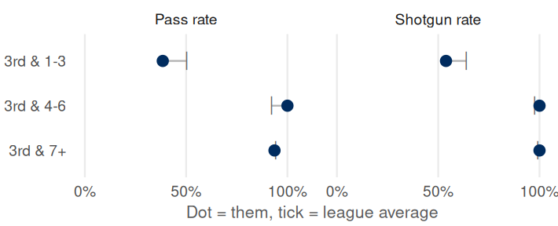

| Distance | Pass rate | EPA/play | Plays |
| --- | --- | --- | --- |
| 3rd & 1-3 | 38% (27th) | +0.05 (14th) | 39 |
| 3rd & 4-6 | 100% (1st) | -0.13 (23rd) | 24* |
| 3rd & 7+ | 94% (19th) | -0.24 (23rd) | 47 |

### Red zone: run-first (42% pass rate)

| Metric | Value | NFL rank | League avg | Last season | Plays |
| --- | --- | --- | --- | --- | --- |
| Pass rate | 42% | 30th | 53% | 51% (23rd) | 67 |
| Pass rate over expected | -14 pts | 29th | -5 pts | -5 pts (18th) | 67 |
| EPA per play | -0.15 | 29th | +0.04 | +0.10 (10th) | 67 |

### Tendency shifts: 1 change in the last 4 games

| Situation | Metric | Season | Last 4 | Change | Plays (last 4) |
| --- | --- | --- | --- | --- | --- |
| Early downs | Pass rate over expected | -4 pts | -4 pts | -1 pts | 169 |
| Early downs | Shotgun rate | 55% | 59% | +3 pts | 169 |
| Early downs | EPA per play | -0.16 | -0.25 | -0.08 | 169 |
| 3rd & 1-3 | Pass rate | 38% | 39% | +0 pts | 18* |
| Red zone | Pass rate | 42% | 35% | -7 pts | 23* |
| All neutral downs | EPA per play | -0.11 | -0.21 | **-0.10** | 221 |

### Most dangerous: runs in the red zone (+0.06 EPA per play vs. -0.06 league)

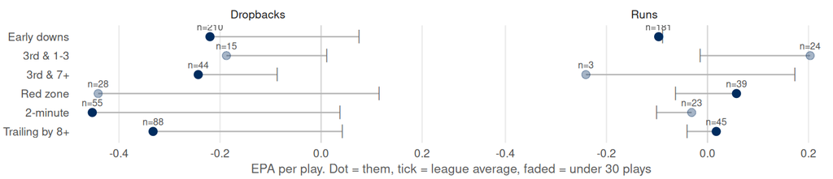

**How to read this.** Pass rate counts sacks and scrambles as passes. *Pass rate over expected* compares their pass rate with what an average team calls in the same down, distance, field position, score and time (nflverse `xpass` model). EPA = expected points added; above 0 is good for the offense. Early downs, 3rd down, red zone and “all neutral” use only plays when the offense’s win probability was 5–95%. The 2-minute and trailing-by-8+ splits use every play. Numbers marked * are under 30 plays: treat them as a hint, not a tendency. Shift = last 4 games differ from the season by 5+ points (0.10 EPA) on 30+ plays. Roster changes lists in-season trades (nflverse trade feed plus a hand-kept list) and other moves seen in weekly rosters; a regular (starting QB, 15%+ of targets, 30%+ of carries, or 60%+ of snaps before the move) is marked ⚠. Data: nflverse play-by-play (nflfastR / nflreadr), openly licensed. Built by Chris Antosiewicz · [source](https://github.com/chrisantosiewicz/nfl-opponent-report).